# Comparing scRNAseq Normalization Methods

Nikolay Oskolkov

September 26, 2017

Abstract

In this lab we will go through main bulk and single cell RNAseq normalization methods and make their comprehensive comparison.

### Load packages

First of all we will load *scran* and *scater* R packages which we are going to use in this lab:

```r
suppressMessages(require(scran))
suppressMessages(require(scater))
suppressMessages(require(edgeR))
suppressMessages(require(matrixStats))
suppressMessages(require(mixOmics))
suppressMessages(require(RColorBrewer))
suppressMessages(require(Rtsne))
suppressMessages(require(limSolve))
suppressMessages(require(DESeq))
suppressMessages(require(tweeDEseq))
```

### Load Expression Values and Metadata

Let start with loading the matrix of raw gene expression counts and filtering away genes with mean rpkm count across all cells below 1. Those genes are lowly expressed genes which should be excluded from the downstream analysis as they might lead to spurious results:

```r
D <- read.table("data/ILC/ensembl_countvalues_ILC.csv",sep=",",header=T,row.names=1)
rpkm <- read.table("data/ILC/ensembl_rpkmvalues_ILC.csv",sep=",",header=T,row.names=1)
D<-D[rowMeans(rpkm)>=1,]
rpkm<-rpkm[rowMeans(rpkm)>=1,]
D[1:5,1:5]
```

```
##                 T74_P1_A9_ILC1 T74_P1_B4_NK T74_P1_B7_ILC2 T74_P1_B9_NK
## ENSG00000000003              0            0              0            0
## ENSG00000000419              0            0              0            0
## ENSG00000000457              0            0              0            0
## ENSG00000000460              1            0              1            0
## ENSG00000000938              0         7067              1            1
##                 T74_P1_D10_ILC2
## ENSG00000000003               0
## ENSG00000000419               0
## ENSG00000000457              66
## ENSG00000000460              40
## ENSG00000000938               1
```

```r
dim(D)
```

```
## [1] 15454   648
```

The rows of the matrix represent Ensembl gene IDs (you can convert them to gene symbols using biomaRt package) from 15454 genes, and the columns are IDs from 648 cells from different individuals sequenced at different plates. To see how many individuals and plates we have let us load the meta-information and have a look:

```r
M <- read.table("data/ILC/Metadata_ILC.csv",sep=",",header=T,row.names=1)
M$Plate<-matrix(unlist(strsplit(as.character(M$Plate),"_")),byrow=TRUE,ncol=2)[,2]
head(M)
```

```
##                 Plate Donor Celltype
## T74_P1_A9_ILC1     P1   T74     ILC1
## T74_P1_B4_NK       P1   T74       NK
## T74_P1_B7_ILC2     P1   T74     ILC2
## T74_P1_B9_NK       P1   T74       NK
## T74_P1_D10_ILC2    P1   T74     ILC2
## T74_P1_E1_ILC3     P1   T74     ILC3
```

Thus we have cells from 3 individuals with IDs:

```r
levels(factor(M$Donor))
```

```
## [1] "T74" "T75" "T86"
```

that were pooled together and sequenced at 4 plates with IDs:

```r
levels(factor(M$Plate))
```

```
## [1] "P1" "P2" "P3" "P4"
```

and finally we have 4 cell-types with the following IDs:

```r
levels(factor(M$Celltype))
```

```
## [1] "ILC1" "ILC2" "ILC3" "NK"
```

We will color cells on the PCA, MDS and tSNE plots by their cell type, donor they came from and plate they were sequenced on, therfore let us add a column of individual colors for each cell type:

```r
Celltype_Colors<-data.frame(Celltype=levels(factor(M$Celltype)),Color=brewer.pal(length(levels(factor(M$Celltype))),'Dark2'))
M$Celltype_Color<-as.character(Celltype_Colors$Color[match(M$Celltype,Celltype_Colors$Celltype)])
Donor_Colors<-data.frame(Donor=levels(factor(M$Donor)),Color=brewer.pal(length(levels(factor(M$Donor))),'Dark2'))
M$Donor_Color<-as.character(Donor_Colors$Color[match(M$Donor,Donor_Colors$Donor)])
Plate_Colors<-data.frame(Plate=levels(factor(M$Plate)),Color=brewer.pal(length(levels(factor(M$Plate))),'Dark2'))
M$Plate_Color<-as.character(Plate_Colors$Color[match(M$Plate,Plate_Colors$Plate)])
head(M)
```

```
##                 Plate Donor Celltype Celltype_Color Donor_Color
## T74_P1_A9_ILC1     P1   T74     ILC1        #1B9E77     #1B9E77
## T74_P1_B4_NK       P1   T74       NK        #E7298A     #1B9E77
## T74_P1_B7_ILC2     P1   T74     ILC2        #D95F02     #1B9E77
## T74_P1_B9_NK       P1   T74       NK        #E7298A     #1B9E77
## T74_P1_D10_ILC2    P1   T74     ILC2        #D95F02     #1B9E77
## T74_P1_E1_ILC3     P1   T74     ILC3        #7570B3     #1B9E77
##                 Plate_Color
## T74_P1_A9_ILC1      #1B9E77
## T74_P1_B4_NK        #1B9E77
## T74_P1_B7_ILC2      #1B9E77
## T74_P1_B9_NK        #1B9E77
## T74_P1_D10_ILC2     #1B9E77
## T74_P1_E1_ILC3      #1B9E77
```

```r
#palette(brewer.pal(length(levels(factor(M$Celltype))),'Dark2'))
```

Finally, before we start comparing different normalization strategies, let us check how many spikes and how many endogenous genes we have after we have filtered the unnormalized and data set:

```r
print(paste0("There are ",sum(grepl("ERCC_",rownames(D))==TRUE)," spikes in the scRNAseq data set after filtering"))
```

```
## [1] "There are 71 spikes in the scRNAseq data set after filtering"
```

```r
D_ERCC<-D[grepl("ERCC_",rownames(D)),]
D_ERCC[1:5,1:5]
```

```
##                                         T74_P1_A9_ILC1 T74_P1_B4_NK
## ERCC_0.11444092:mix1_0.11444092:mix2                 0            1
## ERCC_0.22888184:mix1_0.22888184:mix2..2              4            2
## ERCC_0.22888184:mix1_0.34332275:mix2..1              0            0
## ERCC_0.45776367:mix1_0.11444092:mix2..2              0            0
## ERCC_0.45776367:mix1_0.45776367:mix2                 0            0
##                                         T74_P1_B7_ILC2 T74_P1_B9_NK
## ERCC_0.11444092:mix1_0.11444092:mix2                 1            1
## ERCC_0.22888184:mix1_0.22888184:mix2..2              4            4
## ERCC_0.22888184:mix1_0.34332275:mix2..1              0            0
## ERCC_0.45776367:mix1_0.11444092:mix2..2              0            0
## ERCC_0.45776367:mix1_0.45776367:mix2                 0            0
##                                         T74_P1_D10_ILC2
## ERCC_0.11444092:mix1_0.11444092:mix2                  0
## ERCC_0.22888184:mix1_0.22888184:mix2..2               1
## ERCC_0.22888184:mix1_0.34332275:mix2..1               0
## ERCC_0.45776367:mix1_0.11444092:mix2..2               0
## ERCC_0.45776367:mix1_0.45776367:mix2                  0
```

```r
print(paste0("There are ",sum(grepl("ERCC_",rownames(D))==FALSE)," endogenous genes in the scRNAseq data set after filtering"))
```

```
## [1] "There are 15383 endogenous genes in the scRNAseq data set after filtering"
```

This filtered unnormalized data set we will use later for applying different normalization methods. Note that RPKM normalized data set contains exactly the same genes since we used mean RPKM count above or equalt to 1 as criterion for filtering.

### Defining Visualization Function

Since we are going to repeat the same visualization commands for data sets normalized by different methods, we will define here a function which takes a data set (normalized or unnormalized) and a short description of normalization methods and produces a bunch of informatice plots. There is no need to go through the code of the function, it is not difficult but bulky.

```r
#Here df is a matrix with samples as columns and features as rows
#description is supposed to say something about normalization, i.e. "RAW", "RPKM", "DECONVOLUTION"
norm_function<-function(df,description)
{
df_ERCC<-df[grepl("ERCC_",rownames(df)),]
mean_expr<-as.numeric(rowMeans(df,na.rm=TRUE))
sd_expr<-rowSds(as.matrix(df),na.rm=TRUE)
cv_squared_expr<-(sd_expr/mean_expr)^2
par(mfrow=c(1,1))
plot(log10(cv_squared_expr)~log10(mean_expr),pch=20,cex=0.5,xlab=paste0("log10 ( MEAN ",description," COUNT )"),ylab="log10 ( CV² )",main=paste0(description," COUNTS"))

mean_expr_ercc<-as.numeric(rowMeans(df_ERCC,na.rm=TRUE))
sd_expr_ercc<-rowSds(as.matrix(df_ERCC),na.rm=TRUE)
cv_squared_expr_ercc<-(sd_expr_ercc/mean_expr_ercc)^2
mean_expr_ercc_filtered<-mean_expr_ercc
cv_squared_expr_ercc_filtered<-cv_squared_expr_ercc
#mean_expr_ercc_filtered<-mean_expr_ercc[!(log10(mean_expr_ercc)<1 & log10(cv_squared_expr_ercc)<1)]
#cv_squared_expr_ercc_filtered<-cv_squared_expr_ercc[!(log10(mean_expr_ercc)<1 & log10(cv_squared_expr_ercc)<1)]
points(log10(cv_squared_expr_ercc_filtered)~log10(mean_expr_ercc_filtered),col="red",pch=20,cex=1.5)

#FIT SPIKEINS WITH A CURVE
fit_expr_ercc<-loess(log10(cv_squared_expr_ercc_filtered)[is.finite(log10(mean_expr_ercc_filtered))]~log10(mean_expr_ercc_filtered)[is.finite(log10(mean_expr_ercc_filtered))],span=1)
j<-order(log10(mean_expr_ercc_filtered)[is.finite(log10(mean_expr_ercc_filtered))])
lines(fit_expr_ercc$fitted[j]~log10(mean_expr_ercc_filtered)[is.finite(log10(mean_expr_ercc_filtered))][j],col="red",lwd=3)
pred_expr<-predict(fit_expr_ercc,log10(mean_expr))

#DETERMINE VARIABLE GENES THAT ARE ABOVE THE SPIKEINS CURVE
filtered_expr<-df[log10(cv_squared_expr)>=pred_expr,]
filtered_expr<-filtered_expr[grepl("NA",rownames(filtered_expr))==FALSE,]
text(3,2.5,paste0(dim(filtered_expr)[1]," variable genes"))

#PCA PLOT WITH MIX_OMICS
pca.ALL<-pca(log10(t(filtered_expr+1)),ncomp=10,center=TRUE,scale=FALSE)
plot(pca.ALL)
plotIndiv(pca.ALL,group=factor(M$Celltype),ind.names=FALSE,ellipse=FALSE,legend=TRUE,title=paste0("PCA PLOT WITH MIX_OMICS: ",description," COUNTS"),cex=1)

par(mfrow=c(2,2))
#MDS PLOT WITH PLOT_MDS
library("edgeR")
cds_expr<-DGEList(filtered_expr)
plotMDS(cds_expr,pch=1,main=paste0("MDS PLOT WITH PLOT_MDS: ",description," COUNTS"),col=M$Celltype_Color,top=dim(filtered_expr)[1])
mtext("plotMDS did transposing, adding offset and log-transforming")
legend("topleft",levels(M$Celltype),cex=1,fill=levels(factor(M$Celltype_Color)),inset=0.02)

library("edgeR")
plotMDS(log10(filtered_expr+1),pch=1,main=paste0("MDS PLOT WITH PLOT_MDS: ",description," COUNTS"),col=M$Celltype_Color,top=dim(filtered_expr)[1])
mtext("Manual transposing, adding offset and log-transforming")
legend("topleft",levels(M$Celltype),cex=1,fill=levels(factor(M$Celltype_Color)),inset=0.02)

#MDS PLOT WITH CMDSCALE
d<-dist(log10(t(filtered_expr+1)))
mds<-cmdscale(d,k=2)
plot(mds[,1],mds[,2],main=paste0("MDS PLOT WITH CMDSCALE: ",description," COUNTS"),col=M$Celltype_Color)
mtext("We manually constracted the matrix of distances")
legend("topleft",levels(M$Celltype),cex=1,fill=levels(factor(M$Celltype_Color)),inset=0.02)

#PCA PLOT WITH PRCOMP
PC<-prcomp(log10(t(filtered_expr+1)),center=TRUE,scale=FALSE)
plot(PC$x[,1:2],col=M$Celltype_Color,main=paste0("PCA PLOT WITH PRCOMP: ",description," COUNTS"))
mtext("Manual transposing, adding offset and log-transforming")
legend("topleft",levels(M$Celltype),cex=1,fill=levels(factor(M$Celltype_Color)),inset=0.02)

#TSNE PLOT
library("Rtsne")
set.seed(1)
tsne.out_expr<-Rtsne(t(log10(filtered_expr+1)),initial_dims=20,verbose=TRUE,perplexity=30)
par(mfrow=c(1,1))
plot(tsne.out_expr$Y,main=paste0("tSNE: ",description," COUNTS"),col=M$Celltype_Color,xlab="tSNE1",ylab="tSNE2")
legend("topright",levels(M$Celltype),cex=1,fill=levels(factor(M$Celltype_Color)),inset=0.02)
plot(tsne.out_expr$Y,main=paste0("tSNE: ",description," COUNTS"),col=M$Donor_Color,xlab="tSNE1",ylab="tSNE2")
legend("topright",levels(M$Donor),cex=1,fill=levels(factor(M$Donor_Color)),inset=0.02)
plot(tsne.out_expr$Y,main=paste0("tSNE: ",description," COUNTS"),col=M$Plate_Color,xlab="tSNE1",ylab="tSNE2")
legend("topright",levels(factor(M$Plate)),cex=1,fill=levels(factor(M$Plate_Color)),inset=0.02)
}

cv2_vs_mean_function<-function(df,description,layout)
{
if(layout==2){par(mfrow=c(layout,layout))}
df_ERCC<-df[grepl("ERCC_",rownames(df)),]
mean_expr<-as.numeric(rowMeans(df,na.rm=TRUE))
sd_expr<-rowSds(as.matrix(df),na.rm=TRUE)
cv_squared_expr<-(sd_expr/mean_expr)^2
plot(log10(cv_squared_expr)~log10(mean_expr),pch=20,cex=0.5,xlab=paste0("log10 ( MEAN ",description," COUNT )"),ylab="log10 ( CV² )",main=paste0(description," COUNTS"))

mean_expr_ercc<-as.numeric(rowMeans(df_ERCC,na.rm=TRUE))
sd_expr_ercc<-rowSds(as.matrix(df_ERCC),na.rm=TRUE)
cv_squared_expr_ercc<-(sd_expr_ercc/mean_expr_ercc)^2
mean_expr_ercc_filtered<-mean_expr_ercc
cv_squared_expr_ercc_filtered<-cv_squared_expr_ercc
#mean_expr_ercc_filtered<-mean_expr_ercc[!(log10(mean_expr_ercc)<1 & log10(cv_squared_expr_ercc)<1)]
#cv_squared_expr_ercc_filtered<-cv_squared_expr_ercc[!(log10(mean_expr_ercc)<1 & log10(cv_squared_expr_ercc)<1)]
points(log10(cv_squared_expr_ercc_filtered)~log10(mean_expr_ercc_filtered),col="red",pch=20,cex=1.5)

#FIT SPIKEINS WITH A CURVE
fit_expr_ercc<-loess(log10(cv_squared_expr_ercc_filtered)[is.finite(log10(mean_expr_ercc_filtered))]~log10(mean_expr_ercc_filtered)[is.finite(log10(mean_expr_ercc_filtered))],span=1)
j<-order(log10(mean_expr_ercc_filtered)[is.finite(log10(mean_expr_ercc_filtered))])
lines(fit_expr_ercc$fitted[j]~log10(mean_expr_ercc_filtered)[is.finite(log10(mean_expr_ercc_filtered))][j],col="red",lwd=3)
pred_expr<-predict(fit_expr_ercc,log10(mean_expr))

#DETERMINE VARIABLE GENES THAT ARE ABOVE THE SPIKEINS CURVE
filtered_expr<-df[log10(cv_squared_expr)>=pred_expr,]
filtered_expr<-filtered_expr[grepl("NA",rownames(filtered_expr))==FALSE,]
text(3,2.5,paste0(dim(filtered_expr)[1]," variable genes"))
}

pca_function<-function(df,description,layout)
{
if(layout==2){par(mfrow=c(layout,layout))}
df_ERCC<-df[grepl("ERCC_",rownames(df)),]
mean_expr<-as.numeric(rowMeans(df,na.rm=TRUE))
sd_expr<-rowSds(as.matrix(df),na.rm=TRUE)
cv_squared_expr<-(sd_expr/mean_expr)^2

mean_expr_ercc<-as.numeric(rowMeans(df_ERCC,na.rm=TRUE))
sd_expr_ercc<-rowSds(as.matrix(df_ERCC),na.rm=TRUE)
cv_squared_expr_ercc<-(sd_expr_ercc/mean_expr_ercc)^2
mean_expr_ercc_filtered<-mean_expr_ercc
cv_squared_expr_ercc_filtered<-cv_squared_expr_ercc

#FIT SPIKEINS WITH A CURVE
fit_expr_ercc<-loess(log10(cv_squared_expr_ercc_filtered)[is.finite(log10(mean_expr_ercc_filtered))]~log10(mean_expr_ercc_filtered)[is.finite(log10(mean_expr_ercc_filtered))],span=1)
j<-order(log10(mean_expr_ercc_filtered)[is.finite(log10(mean_expr_ercc_filtered))])
pred_expr<-predict(fit_expr_ercc,log10(mean_expr))

#DETERMINE VARIABLE GENES THAT ARE ABOVE THE SPIKEINS CURVE
filtered_expr<-df[log10(cv_squared_expr)>=pred_expr,]
filtered_expr<-filtered_expr[grepl("NA",rownames(filtered_expr))==FALSE,]

#PCA PLOT WITH PRCOMP
PC<-prcomp(log10(t(filtered_expr+1)),center=TRUE,scale=FALSE)
plot(PC$x[,1:2],col=M$Celltype_Color,main=paste0("PCA PLOT: ",description," COUNTS"))
legend("topleft",levels(M$Celltype),cex=1,fill=levels(factor(M$Celltype_Color)),inset=0.02)
}


tsne_function<-function(df,description,layout)
{
if(layout==2){par(mfrow=c(layout,layout))}
df_ERCC<-df[grepl("ERCC_",rownames(df)),]
mean_expr<-as.numeric(rowMeans(df,na.rm=TRUE))
sd_expr<-rowSds(as.matrix(df),na.rm=TRUE)
cv_squared_expr<-(sd_expr/mean_expr)^2

mean_expr_ercc<-as.numeric(rowMeans(df_ERCC,na.rm=TRUE))
sd_expr_ercc<-rowSds(as.matrix(df_ERCC),na.rm=TRUE)
cv_squared_expr_ercc<-(sd_expr_ercc/mean_expr_ercc)^2
mean_expr_ercc_filtered<-mean_expr_ercc
cv_squared_expr_ercc_filtered<-cv_squared_expr_ercc

#FIT SPIKEINS WITH A CURVE
fit_expr_ercc<-loess(log10(cv_squared_expr_ercc_filtered)[is.finite(log10(mean_expr_ercc_filtered))]~log10(mean_expr_ercc_filtered)[is.finite(log10(mean_expr_ercc_filtered))],span=1)
j<-order(log10(mean_expr_ercc_filtered)[is.finite(log10(mean_expr_ercc_filtered))])
pred_expr<-predict(fit_expr_ercc,log10(mean_expr))

#DETERMINE VARIABLE GENES THAT ARE ABOVE THE SPIKEINS CURVE
filtered_expr<-df[log10(cv_squared_expr)>=pred_expr,]
filtered_expr<-filtered_expr[grepl("NA",rownames(filtered_expr))==FALSE,]

#TSNE PLOT
library("Rtsne")
set.seed(1)
tsne.out_expr<-Rtsne(t(log10(filtered_expr+1)),initial_dims=20,verbose=TRUE,perplexity=30)
plot(tsne.out_expr$Y,main=paste0("tSNE: ",description," COUNTS"),col=M$Celltype_Color,xlab="tSNE1",ylab="tSNE2")
legend("topright",levels(M$Celltype),cex=1,fill=levels(factor(M$Celltype_Color)),inset=0.02)
}
```

### Raw (Unnormalized) Counts

Let us produce normalization plots for raw (unnormalized) counts:

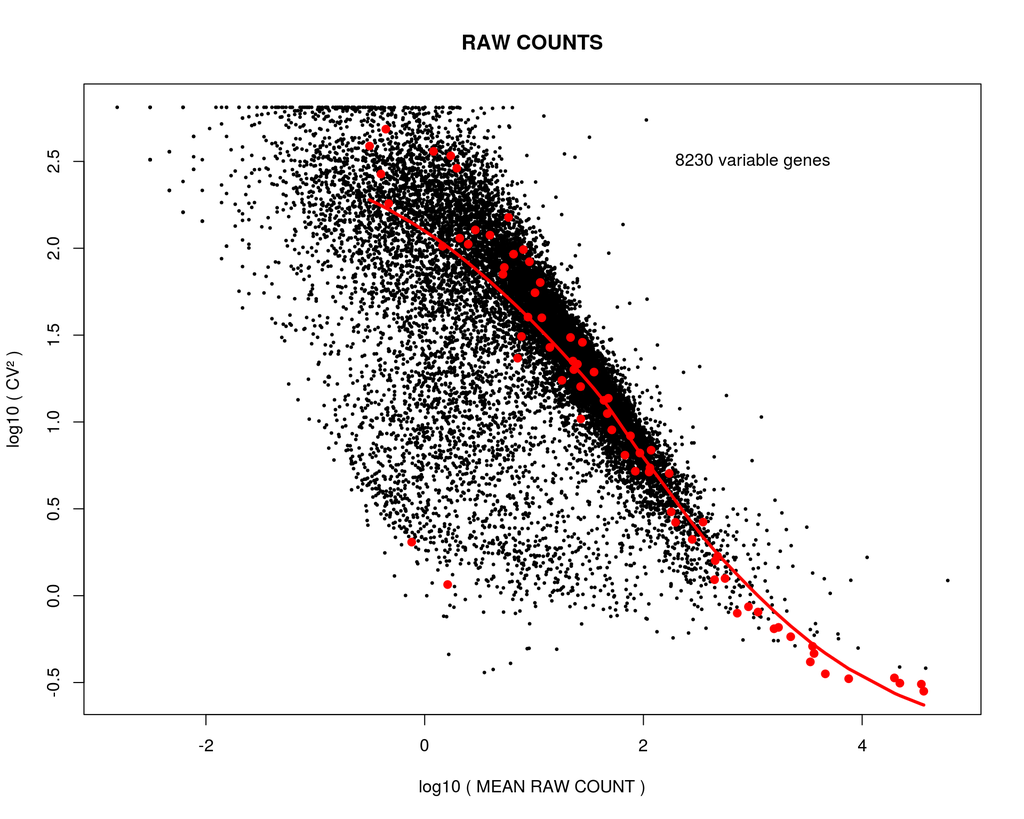

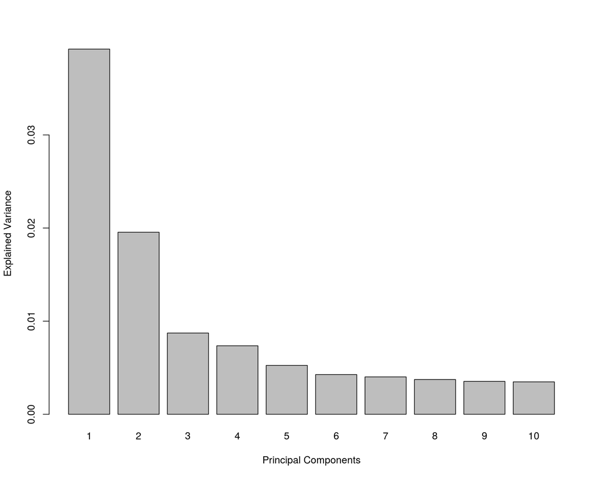

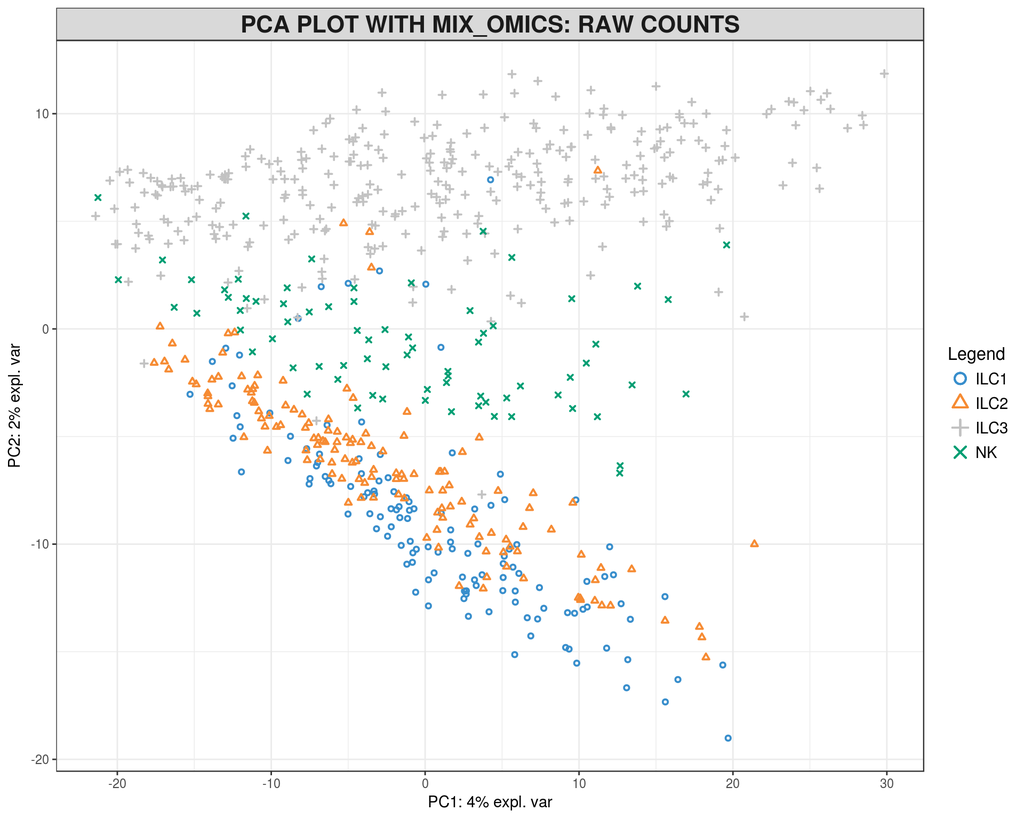

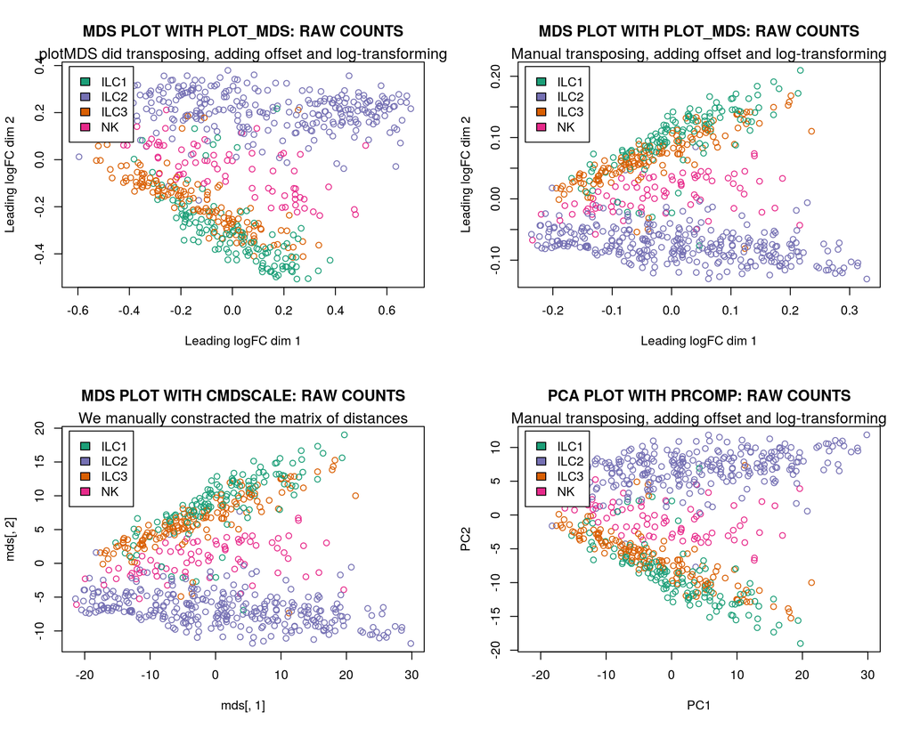

```
## Read the 648 x 20 data matrix successfully!
## Using no_dims = 2, perplexity = 30.000000, and theta = 0.500000
## Computing input similarities...
## Normalizing input...
## Building tree...
##  - point 0 of 648
## Done in 0.31 seconds (sparsity = 0.193725)!
## Learning embedding...
## Iteration 50: error is 58.956671 (50 iterations in 0.49 seconds)
## Iteration 100: error is 56.701754 (50 iterations in 0.37 seconds)
## Iteration 150: error is 56.531546 (50 iterations in 0.39 seconds)
## Iteration 200: error is 56.389438 (50 iterations in 0.38 seconds)
## Iteration 250: error is 56.346676 (50 iterations in 0.37 seconds)
## Iteration 300: error is 0.786285 (50 iterations in 0.34 seconds)
## Iteration 350: error is 0.721567 (50 iterations in 0.32 seconds)
## Iteration 400: error is 0.705333 (50 iterations in 0.33 seconds)
## Iteration 450: error is 0.696797 (50 iterations in 0.34 seconds)
## Iteration 500: error is 0.691368 (50 iterations in 0.33 seconds)
## Iteration 550: error is 0.687286 (50 iterations in 0.33 seconds)
## Iteration 600: error is 0.683649 (50 iterations in 0.34 seconds)
## Iteration 650: error is 0.682050 (50 iterations in 0.34 seconds)
## Iteration 700: error is 0.680340 (50 iterations in 0.34 seconds)
## Iteration 750: error is 0.679271 (50 iterations in 0.34 seconds)
## Iteration 800: error is 0.678175 (50 iterations in 0.34 seconds)
## Iteration 850: error is 0.676960 (50 iterations in 0.34 seconds)
## Iteration 900: error is 0.675525 (50 iterations in 0.36 seconds)
## Iteration 950: error is 0.673548 (50 iterations in 0.36 seconds)
## Iteration 1000: error is 0.673137 (50 iterations in 0.34 seconds)
## Fitting performed in 7.07 seconds.
```

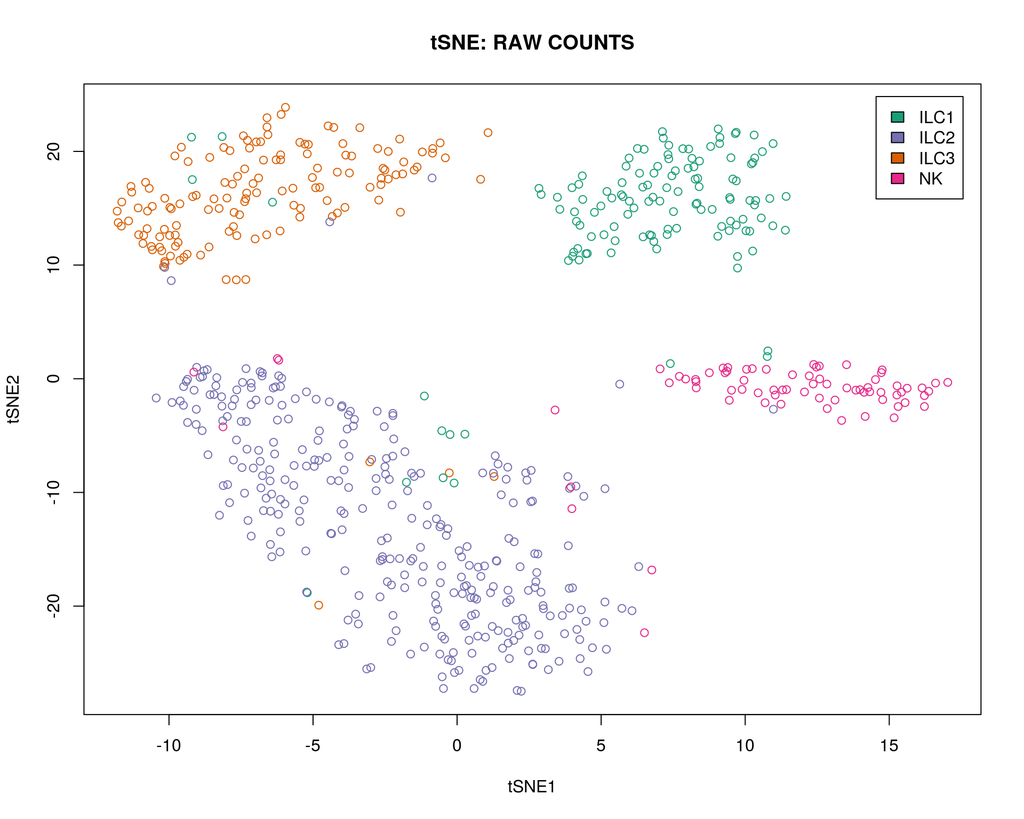

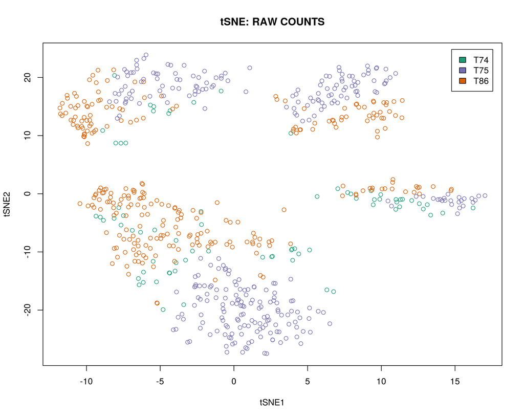

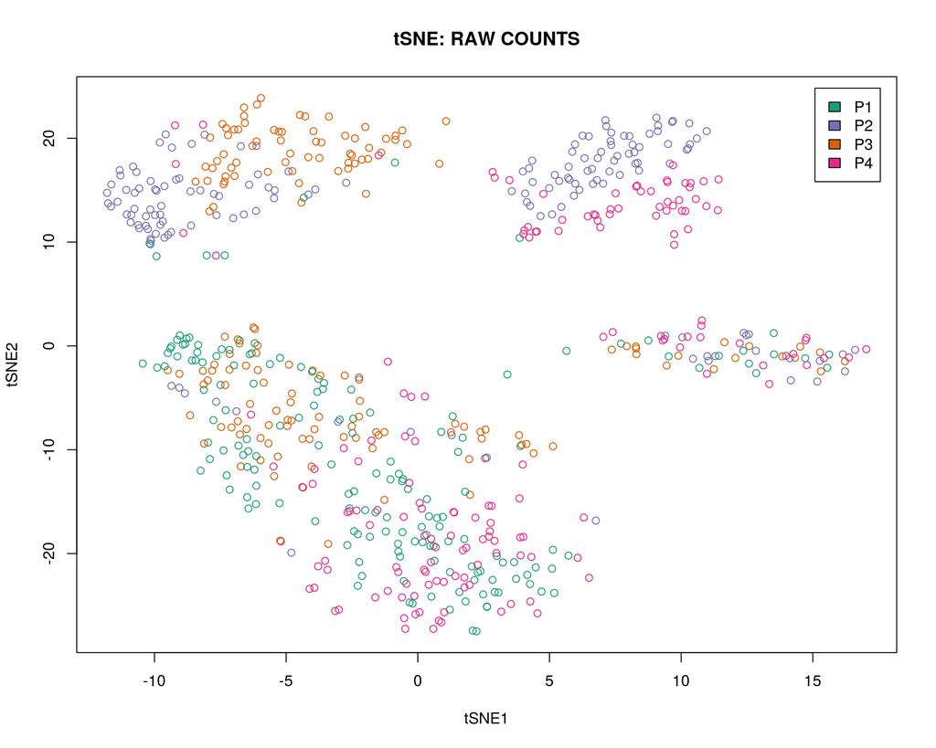

```r
norm_function(D,"RAW")
```

### RPKM Normalized Counts

Let us produce normalization plots for RPKM normalized counts:

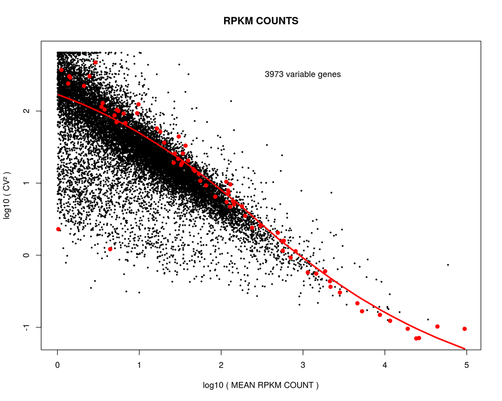

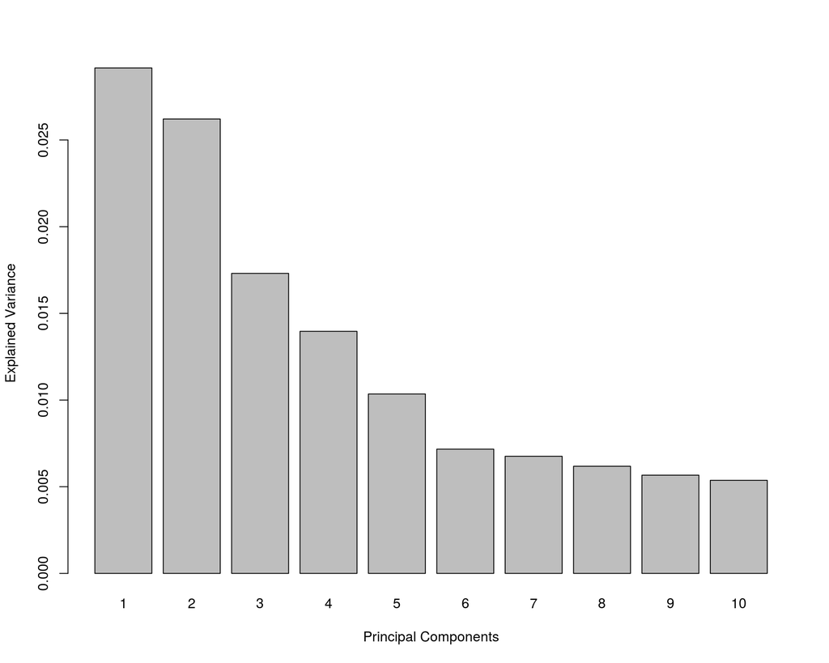

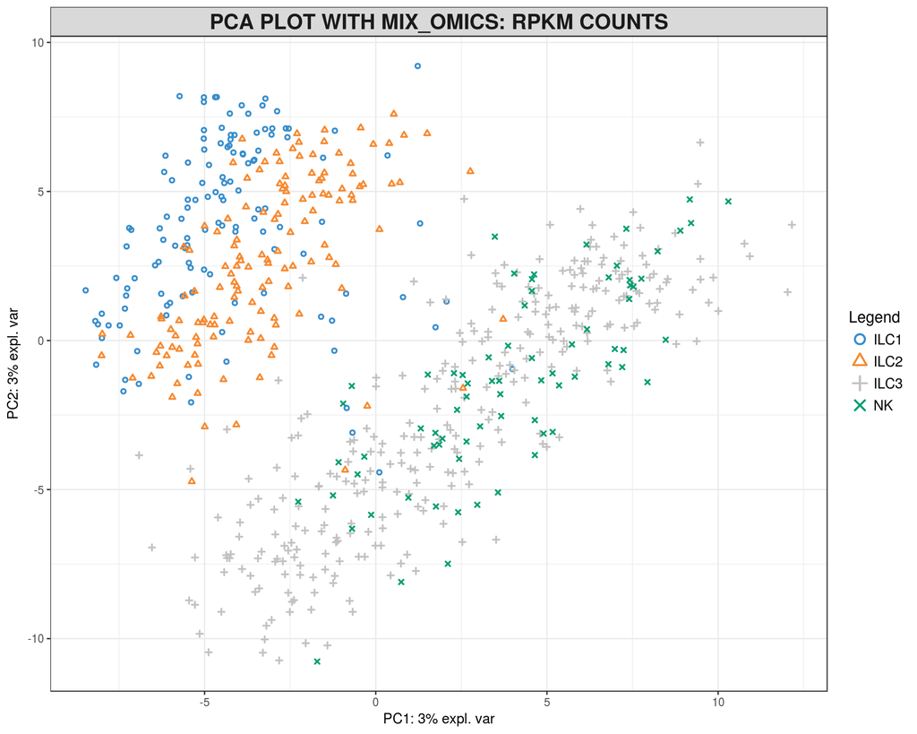

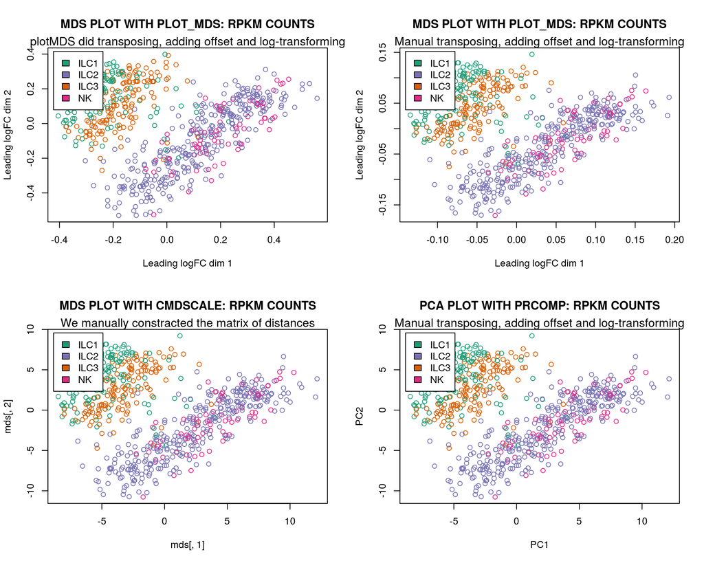

```
## Read the 648 x 20 data matrix successfully!
## Using no_dims = 2, perplexity = 30.000000, and theta = 0.500000
## Computing input similarities...
## Normalizing input...
## Building tree...
##  - point 0 of 648
## Done in 0.32 seconds (sparsity = 0.176826)!
## Learning embedding...
## Iteration 50: error is 64.343052 (50 iterations in 0.49 seconds)
## Iteration 100: error is 59.576464 (50 iterations in 0.40 seconds)
## Iteration 150: error is 59.264640 (50 iterations in 0.35 seconds)
## Iteration 200: error is 59.229132 (50 iterations in 0.35 seconds)
## Iteration 250: error is 59.221925 (50 iterations in 0.34 seconds)
## Iteration 300: error is 1.001312 (50 iterations in 0.31 seconds)
## Iteration 350: error is 0.941608 (50 iterations in 0.30 seconds)
## Iteration 400: error is 0.926302 (50 iterations in 0.30 seconds)
## Iteration 450: error is 0.919973 (50 iterations in 0.30 seconds)
## Iteration 500: error is 0.915720 (50 iterations in 0.30 seconds)
## Iteration 550: error is 0.912045 (50 iterations in 0.29 seconds)
## Iteration 600: error is 0.910266 (50 iterations in 0.30 seconds)
## Iteration 650: error is 0.907985 (50 iterations in 0.30 seconds)
## Iteration 700: error is 0.904823 (50 iterations in 0.30 seconds)
## Iteration 750: error is 0.902205 (50 iterations in 0.30 seconds)
## Iteration 800: error is 0.900130 (50 iterations in 0.29 seconds)
## Iteration 850: error is 0.898579 (50 iterations in 0.30 seconds)
## Iteration 900: error is 0.896747 (50 iterations in 0.30 seconds)
## Iteration 950: error is 0.896096 (50 iterations in 0.29 seconds)
## Iteration 1000: error is 0.894908 (50 iterations in 0.30 seconds)
## Fitting performed in 6.38 seconds.
```

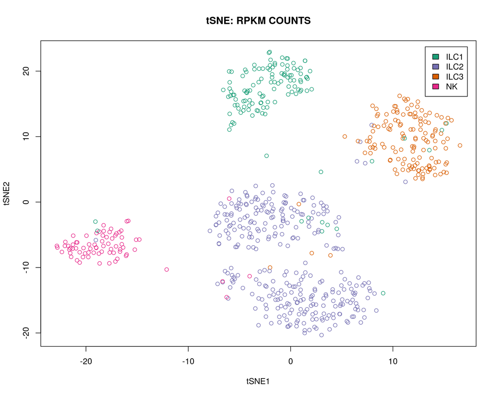

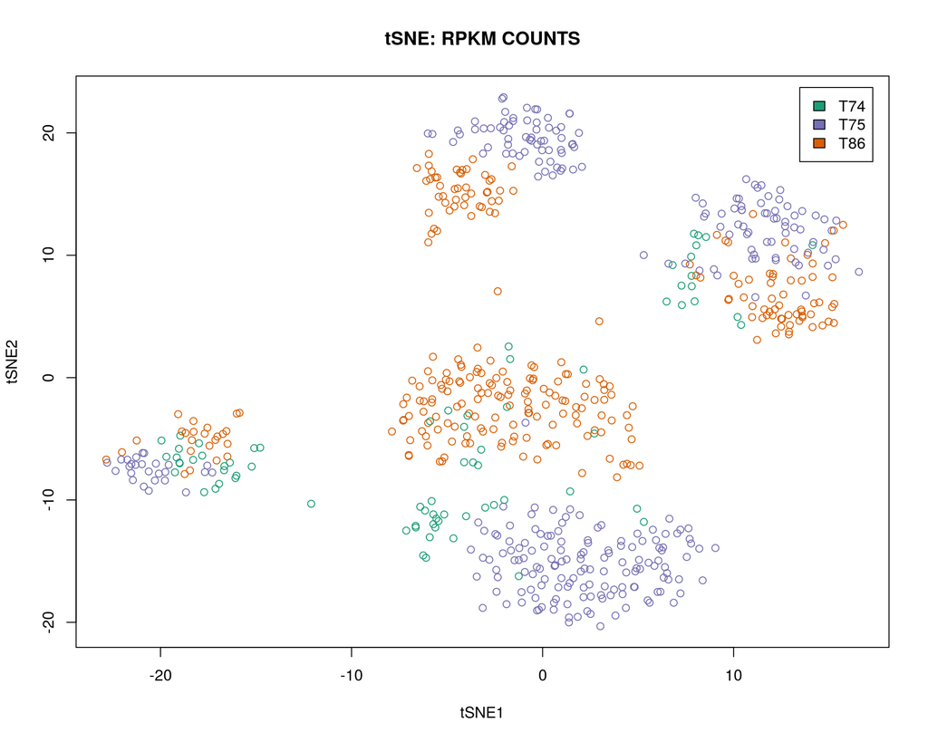

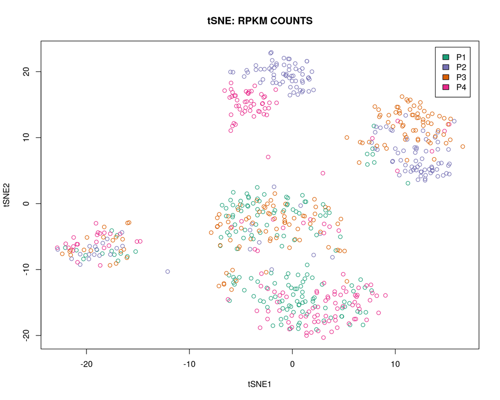

```r
norm_function(rpkm,"RPKM")
```

### Deconvolution Normalization

Further, we will create a *scran* object to be used in the lab:

```r
#out.facs_deconv<-computeSumFactors(as.matrix(D),positive=TRUE)
sce_deconv<-newSCESet(countData=data.frame(D))
sce_deconv<-calculateQCMetrics(sce_deconv,feature_controls=list(MySpikes=rep(c(FALSE,TRUE),c(dim(D)[1]-dim(D_ERCC)[1],dim(D_ERCC)[1]))))
setSpike(sce_deconv) <- "MySpikes"
spikes(sce_deconv)[1:5,1:5] #extracts matrix of spikes
```

```
##                                         T74_P1_A9_ILC1 T74_P1_B4_NK
## ERCC_0.11444092:mix1_0.11444092:mix2                 0            1
## ERCC_0.22888184:mix1_0.22888184:mix2..2              4            2
## ERCC_0.22888184:mix1_0.34332275:mix2..1              0            0
## ERCC_0.45776367:mix1_0.11444092:mix2..2              0            0
## ERCC_0.45776367:mix1_0.45776367:mix2                 0            0
##                                         T74_P1_B7_ILC2 T74_P1_B9_NK
## ERCC_0.11444092:mix1_0.11444092:mix2                 1            1
## ERCC_0.22888184:mix1_0.22888184:mix2..2              4            4
## ERCC_0.22888184:mix1_0.34332275:mix2..1              0            0
## ERCC_0.45776367:mix1_0.11444092:mix2..2              0            0
## ERCC_0.45776367:mix1_0.45776367:mix2                 0            0
##                                         T74_P1_D10_ILC2
## ERCC_0.11444092:mix1_0.11444092:mix2                  0
## ERCC_0.22888184:mix1_0.22888184:mix2..2               1
## ERCC_0.22888184:mix1_0.34332275:mix2..1               0
## ERCC_0.45776367:mix1_0.11444092:mix2..2               0
## ERCC_0.45776367:mix1_0.45776367:mix2                  0
```

```r
clusters <- quickCluster(sce_deconv,get.spikes=FALSE,min.size=199)
sce_deconv <- computeSumFactors(sce_deconv,cluster=clusters)
summary(sizeFactors(sce_deconv))
```

```
##    Min. 1st Qu.  Median    Mean 3rd Qu.    Max.
##  0.1154  0.4842  0.9470  1.0000  1.3857  3.7285
```

```r
sce_deconv <- computeSpikeFactors(sce_deconv, general.use=FALSE)
summary(sizeFactors(sce_deconv))
```

```
##    Min. 1st Qu.  Median    Mean 3rd Qu.    Max.
##  0.1154  0.4842  0.9470  1.0000  1.3857  3.7285
```

```r
head(sce_deconv@phenoData@data$size_factor)
```

```
## [1] 0.2630392 2.5731336 0.9889146 1.1078920 0.4039487 0.8798739
```

```r
head(sce_deconv@phenoData@data$size_factor_MySpikes)
```

```
## [1] 0.6519482 2.7998218 2.5414232 2.3246439 0.9562505 0.7434053
```

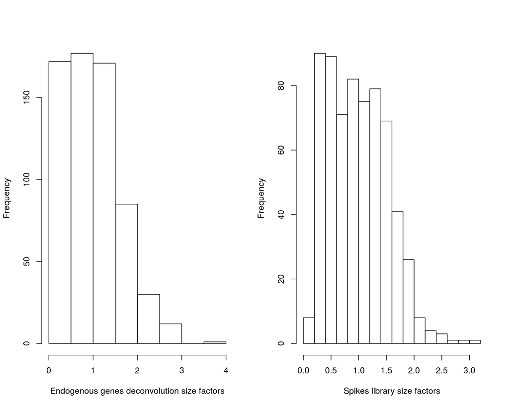

```r
par(mfrow=c(1,2))
hist(sce_deconv@phenoData@data$size_factor,xlab="Endogenous genes deconvolution size factors",main="")
hist(sce_deconv@phenoData@data$size_factor_MySpikes,xlab="Spikes library size factors",main="")
```

```r
sce_deconv<-normalize(sce_deconv)

expr_deconv<-as.data.frame(t(apply(D[grepl("ERCC_",rownames(D))==FALSE,],1,"/",sce_deconv@phenoData@data$size_factor)))
expr_deconv_ercc<-as.data.frame(t(apply(D_ERCC,1,"/",sce_deconv@phenoData@data$size_factor_MySpikes)))
expr_deconv_merge<-rbind(expr_deconv,expr_deconv_ercc)

#Detecting highly variable genes
batch <- M$Donor
design <- model.matrix(~batch)
alt.fit <- trendVar(sce_deconv, design=design)
alt.decomp <- decomposeVar(sce_deconv, alt.fit)
top.hvgs <- order(alt.decomp$bio, decreasing=TRUE)
head(alt.decomp[top.hvgs,])
```

```
##                      mean    total      bio       tech       p.value
## ENSG00000118503  8.323345 15.25517 9.705040  5.5501310 6.396407e-106
## ENSG00000170345 11.851935  9.95590 9.514889  0.4410109  0.000000e+00
## ENSG00000121966  8.790955 12.74023 8.594294  4.1459400 8.492808e-136
## ENSG00000019582  8.468209 13.52744 8.465622  5.0618201  3.608128e-99
## ENSG00000188404  6.931418 20.27780 8.425106 11.8526971  1.384887e-26
## ENSG00000087074  8.789887 12.43043 8.281834  4.1485955 1.388317e-128
##                           FDR
## ENSG00000118503 5.787996e-103
## ENSG00000170345  0.000000e+00
## ENSG00000121966 8.709657e-133
## ENSG00000019582  2.921255e-96
## ENSG00000188404  4.734158e-24
## ENSG00000087074 1.334780e-125
```

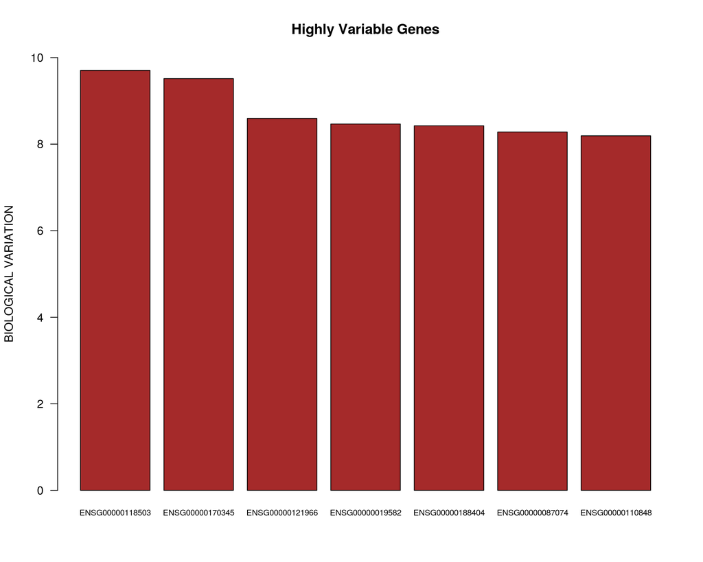

```r
par(mfrow=c(1,1))
barplot(as.numeric(alt.decomp[top.hvgs,]$bio)[1:7],names.arg=rownames(alt.decomp[top.hvgs,])[1:7],las=1,ylim=c(0,10),main="Highly Variable Genes",cex.names=0.7,col="brown",ylab="BIOLOGICAL VARIATION")
```

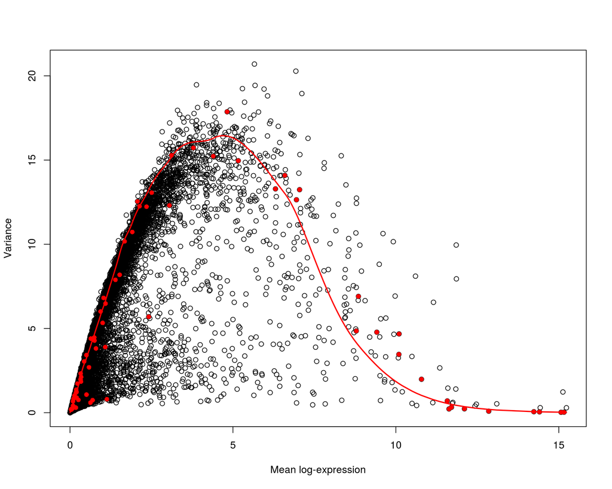

```r
plot(alt.decomp$mean, alt.decomp$total, xlab="Mean log-expression", ylab="Variance")
o <- order(alt.decomp$mean)
lines(alt.decomp$mean[o], alt.decomp$tech[o], col="red", lwd=2)
points(alt.fit$mean, alt.fit$var, col="red", pch=16)
```

```r
#Detecting correlated genes
null.dist <- correlateNull(design=design)
cor.pairs <- correlatePairs(sce_deconv[top.hvgs[1:200],], null.dist=null.dist, design=design)
head(cor.pairs)
```

```
##             gene1           gene2       rho      p.value         FDR
## 1 ENSG00000170345 ENSG00000120129 0.7198931 1.999998e-06 2.82311e-05
## 2 ENSG00000120129 ENSG00000157514 0.5877672 1.999998e-06 2.82311e-05
## 3 ENSG00000162594 ENSG00000104951 0.5643329 1.999998e-06 2.82311e-05
## 4 ENSG00000170345 ENSG00000157514 0.5502744 1.999998e-06 2.82311e-05
## 5 ENSG00000184009 ENSG00000075624 0.5338644 1.999998e-06 2.82311e-05
## 6 ENSG00000170345 ENSG00000087074 0.5221032 1.999998e-06 2.82311e-05
##   limited
## 1    TRUE
## 2    TRUE
## 3    TRUE
## 4    TRUE
## 5    TRUE
## 6    TRUE
```

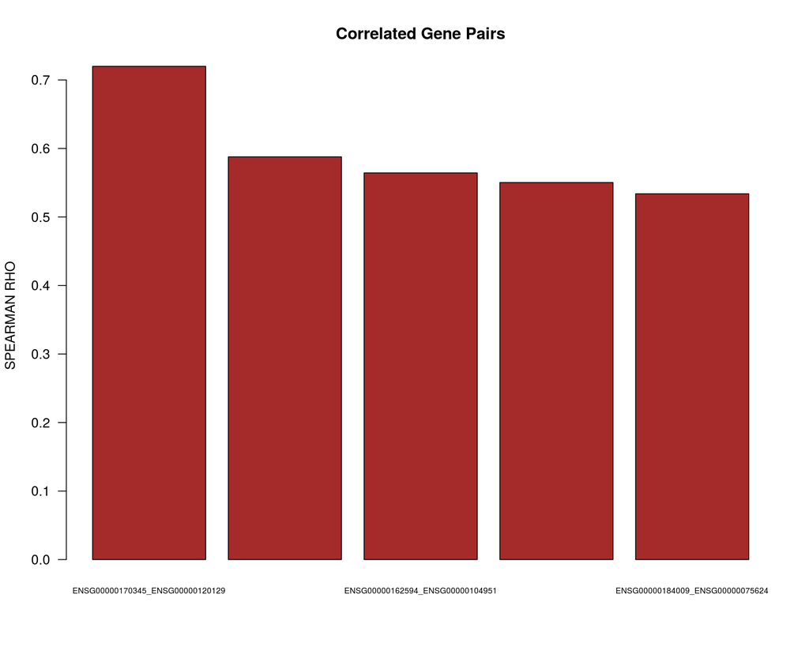

```r
barplot(abs(as.numeric(cor.pairs$rho))[1:5],names.arg=paste(cor.pairs$gene1[1:5],cor.pairs$gene2[1:5],sep="_"),las=1,main="Correlated Gene Pairs",cex.names=0.6,col="brown",ylab="SPEARMAN RHO")
```

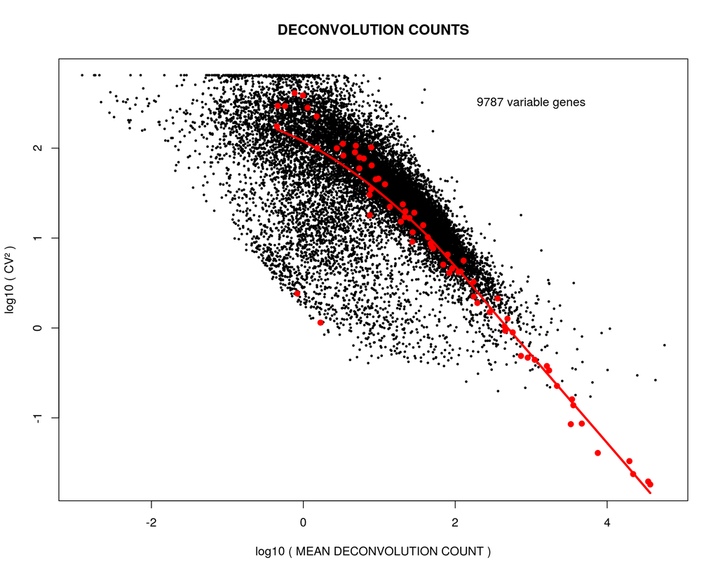

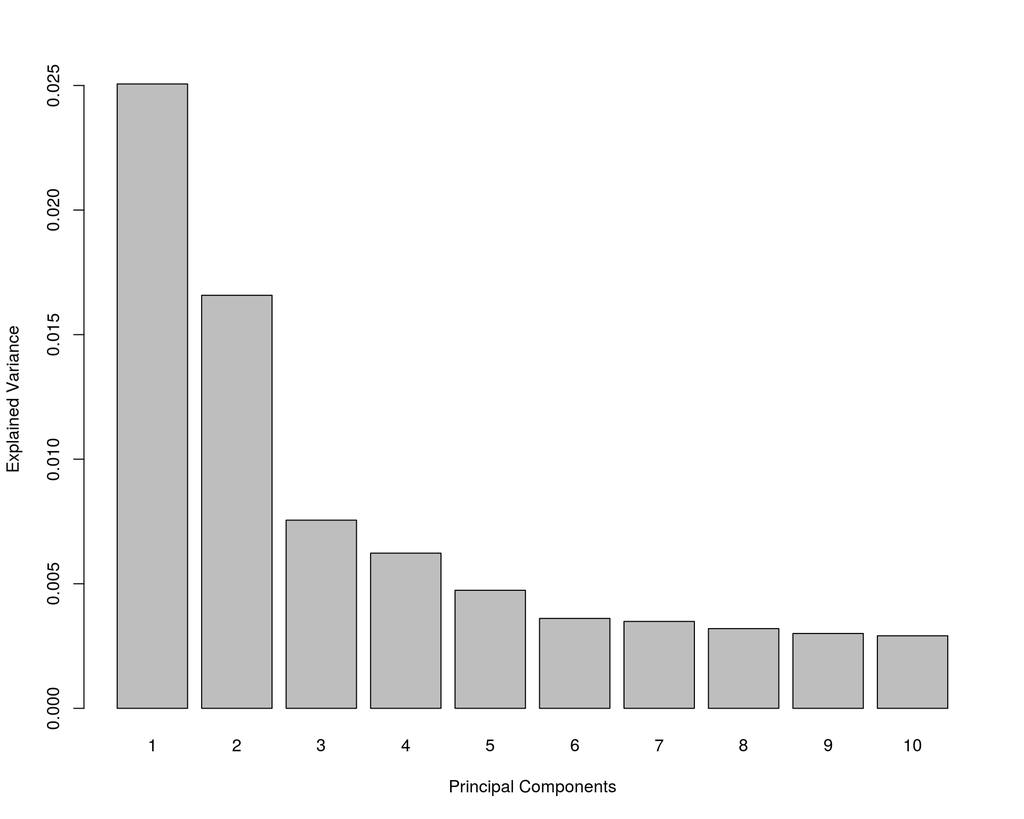

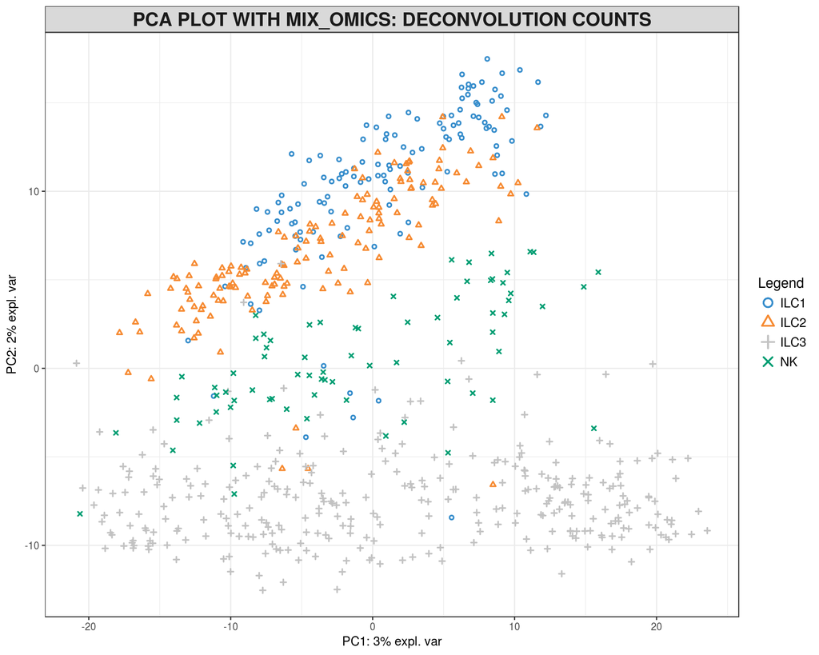

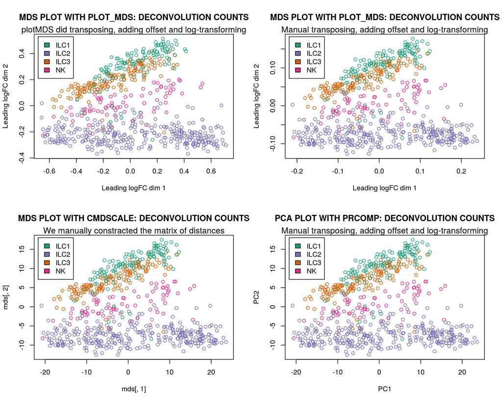

[output not shown]

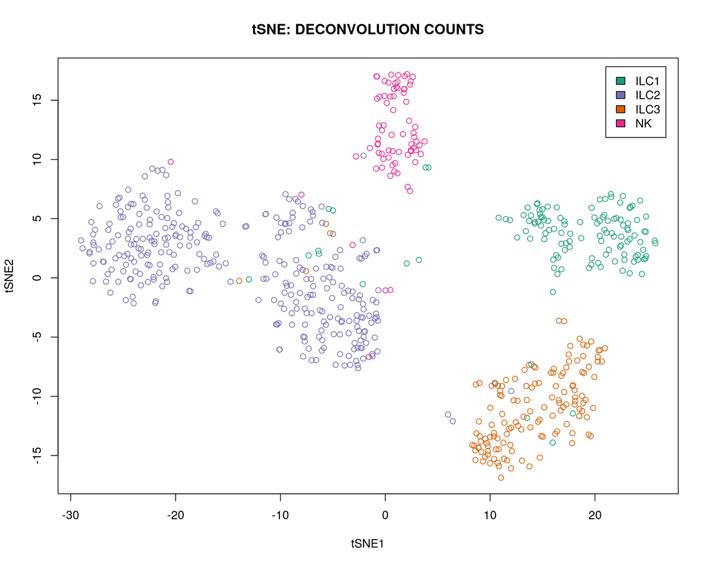

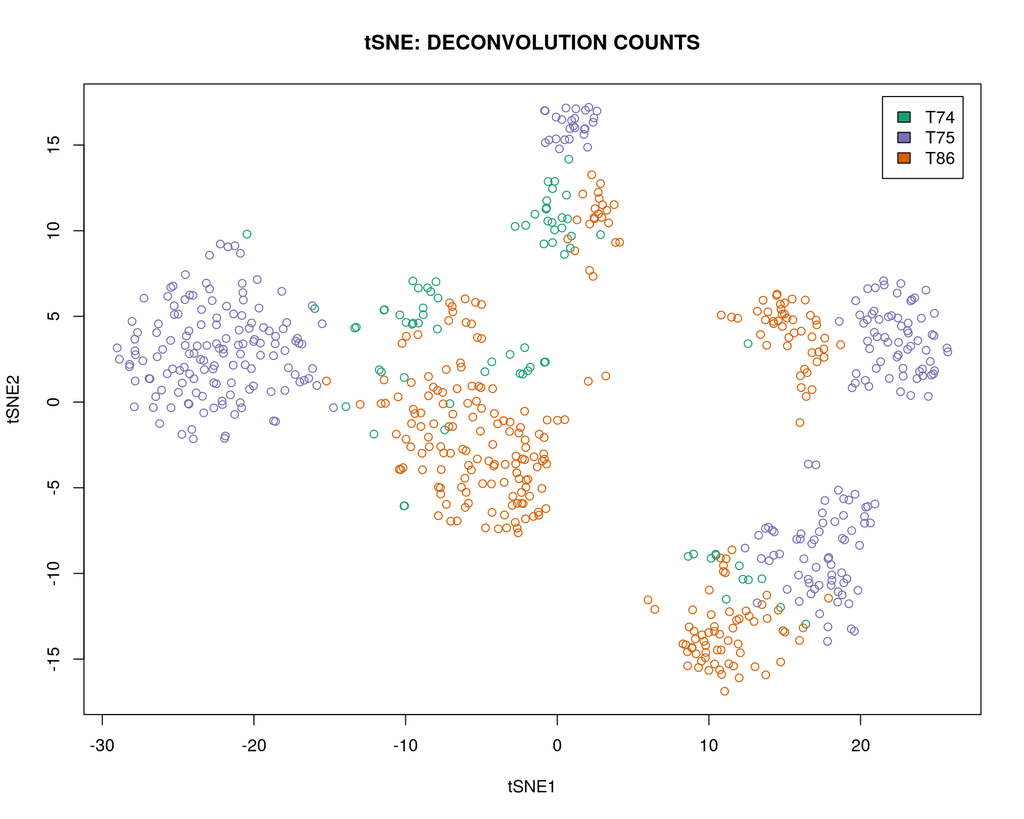

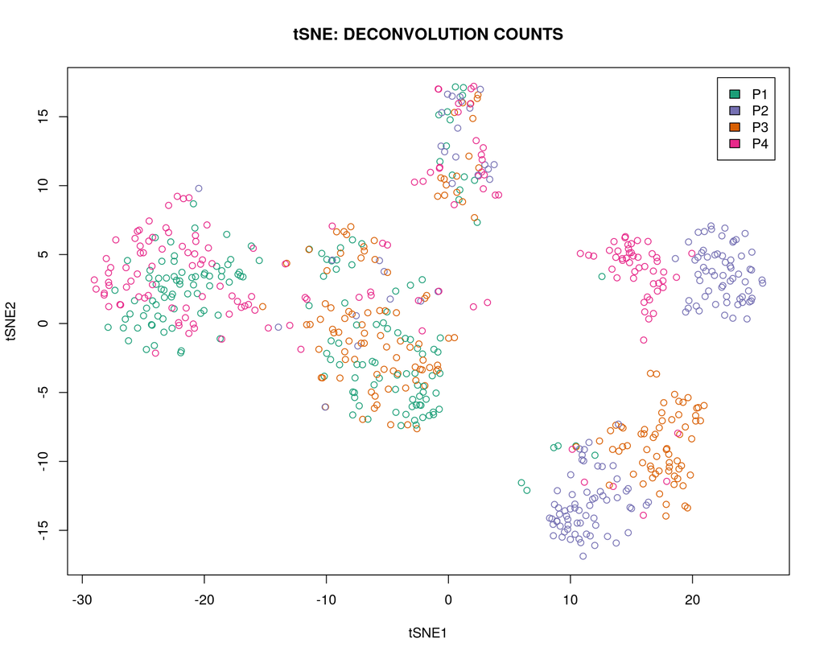

```r
norm_function(expr_deconv_merge,"DECONVOLUTION")
```

### Spike Library Size Normalization

Now let us normalize both endogenous genes and spikes by spikes library sizes:

```r
sce_spike<-newSCESet(countData=data.frame(D))
sce_spike<-calculateQCMetrics(sce_spike,feature_controls=list(MySpikes=rep(c(FALSE,TRUE),c(dim(D)[1]-dim(D_ERCC)[1],dim(D_ERCC)[1]))))
setSpike(sce_spike) <- "MySpikes"
spikes(sce_spike)[1:5,1:5] #extracts matrix of spikes
```

```
##                                         T74_P1_A9_ILC1 T74_P1_B4_NK
## ERCC_0.11444092:mix1_0.11444092:mix2                 0            1
## ERCC_0.22888184:mix1_0.22888184:mix2..2              4            2
## ERCC_0.22888184:mix1_0.34332275:mix2..1              0            0
## ERCC_0.45776367:mix1_0.11444092:mix2..2              0            0
## ERCC_0.45776367:mix1_0.45776367:mix2                 0            0
##                                         T74_P1_B7_ILC2 T74_P1_B9_NK
## ERCC_0.11444092:mix1_0.11444092:mix2                 1            1
## ERCC_0.22888184:mix1_0.22888184:mix2..2              4            4
## ERCC_0.22888184:mix1_0.34332275:mix2..1              0            0
## ERCC_0.45776367:mix1_0.11444092:mix2..2              0            0
## ERCC_0.45776367:mix1_0.45776367:mix2                 0            0
##                                         T74_P1_D10_ILC2
## ERCC_0.11444092:mix1_0.11444092:mix2                  0
## ERCC_0.22888184:mix1_0.22888184:mix2..2               1
## ERCC_0.22888184:mix1_0.34332275:mix2..1               0
## ERCC_0.45776367:mix1_0.11444092:mix2..2               0
## ERCC_0.45776367:mix1_0.45776367:mix2                  0
```

```r
sce_spike <- computeSpikeFactors(sce_spike,general.use=TRUE)
summary(sizeFactors(sce_spike))
```

```
##    Min. 1st Qu.  Median    Mean 3rd Qu.    Max.
##  0.1466  0.5450  0.9735  1.0000  1.3861  3.1264
```

```r
head(sce_spike@phenoData@data$size_factor)
```

```
## [1] 0.6519482 2.7998218 2.5414232 2.3246439 0.9562505 0.7434053
```

```r
head(sce_spike@phenoData@data$size_factor_MySpikes)
```

```
## [1] 0.6519482 2.7998218 2.5414232 2.3246439 0.9562505 0.7434053
```

```r
expr_spike<-as.data.frame(t(apply(D,1,"/",sce_spike@phenoData@data$size_factor)))
```

Let us produce normalization plots for counts normalized by spike library sizes:

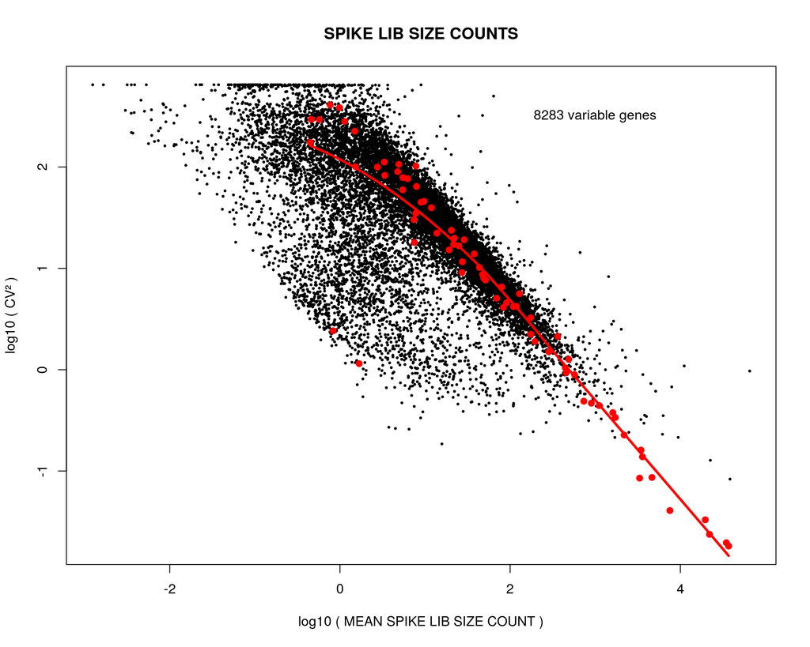

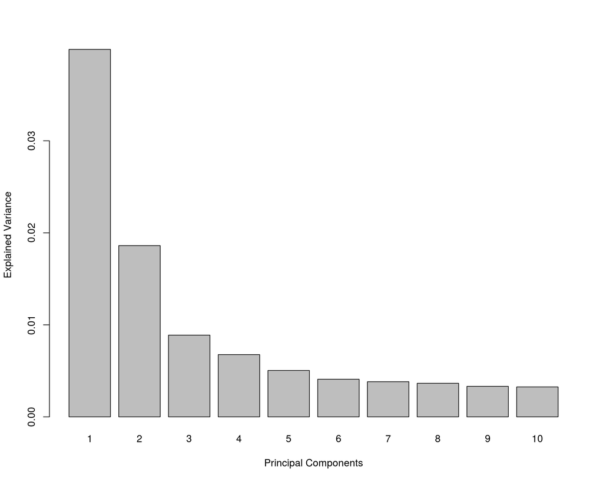

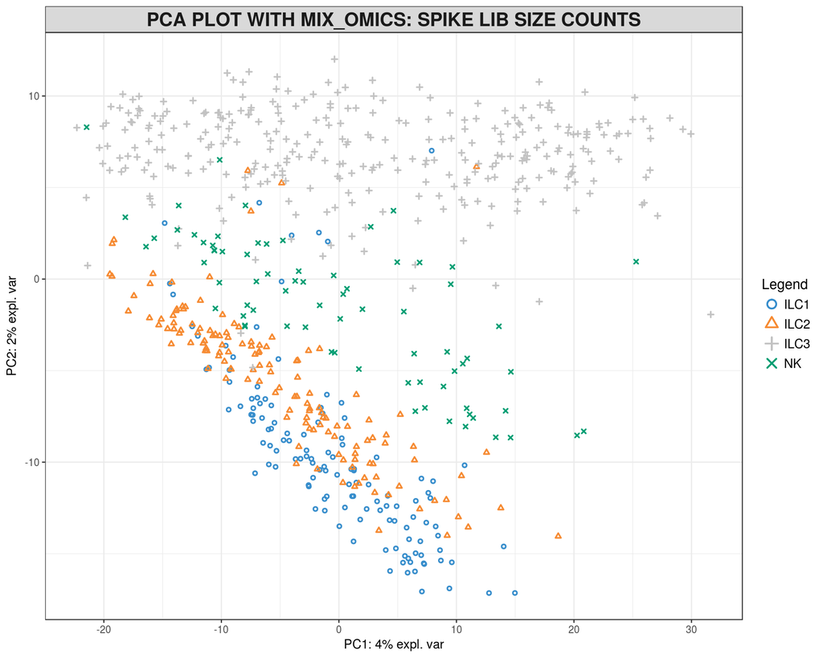

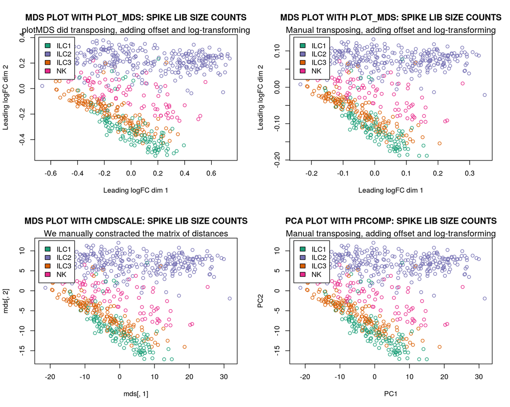

[output not shown]

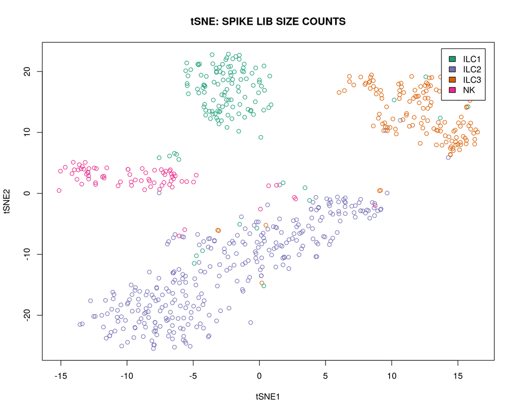

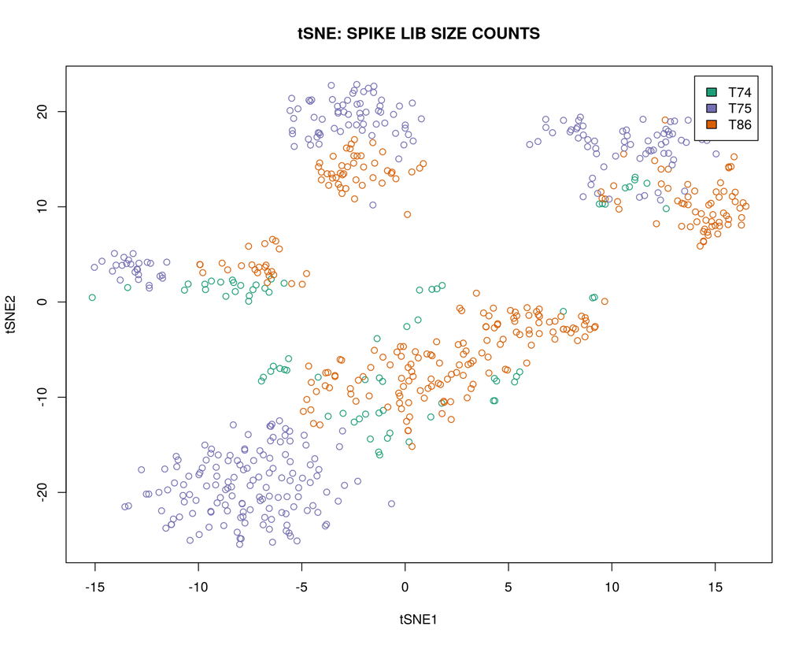

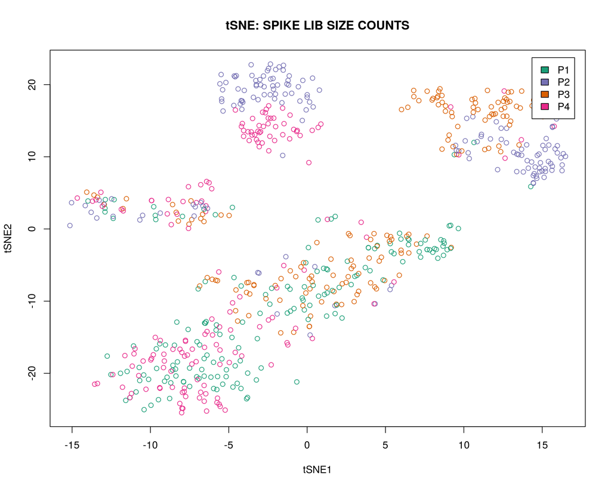

```r
norm_function(expr_spike,"SPIKE LIB SIZE")
```